# Anna Khazenzon, Homework 2, 10/8/14

```r
library(ggplot2)
library(scales)
```

## Question 1

Here, we calculate mean, sum of squares, variance, standard deviation, and standard error for a sample (*N*=3).

```r
sample <- c(1, 1, 0)

s_mean <- (sample[1] + sample[2] + sample[3])/(length(sample))
s_ss <- (sample[1] - s_mean)^2 + (sample[2] - s_mean)^2 + (sample[3] - s_mean)^2
s_var <- s_ss/(length(sample) - 1)
s_sd <- sqrt(s_ss/(length(sample) - 1))
s_se <- s_sd/sqrt(length(sample))
```

The equation to calculate the sample mean $\bar{x}$ is:

$\bar{x} = \frac{\sum_{i=1}^{n} x_i}{n}$

For our sample, the mean $\bar{x}$ is 0.6667.

The equation to calculate sum of squares $SS$ is:

$SS = \sum_{i=1}^{n} (x_i - \bar{x})^2$

For our sample, the sum of squares $SS$ is 0.6667.

The equation to calculate variance $s^2$ is:

$s^2 = \frac{SS}{n - 1}$

For our sample, the variance $s^2$ is 0.3333.

The equation to calculate sample standard deviation $s$ is:

$s = \sqrt{\frac{SS}{n - 1}}$

For our sample, the standard deviation $s$ is 0.5774.

The equation to calculate standard error of $\bar{x}$, $SE_\bar{x}$ is:

$SE_\bar{x} = \frac{s}{\sqrt{n}}$

For our sample, the standard error of $\bar{x}$, $SE_\bar{x}$ is 0.3333.

## Question 6

Within the memory bias experiment dataset, we were interested in whether *Past Happiness* and *Future Happiness* were differentially related across *Memory Group* (free, biased, varied). To explore this, we looked at the correlations and plots of *Past Happiness* and *Future Happiness* within each *Memory Group*.

```r
memdata <- read.csv('http://web.stanford.edu/class/psych252/_downloads/hw2data.csv',header=T, sep=',')

#Type = exper cond, 1=free, 2=biased, 3=varied
#Pasthapp = rating
#Responsible = self-reported feelings of responsibility
#Futurehapp = rating of expected future happiness
#FTP = future time perspective
#complain = yes/no for whether participants considered complaining

# from Q3, recoded variables
# look at data ranges and histograms to determine how to recode
sapply(memdata, range)
```

```
##      Type Pasthapp Responsible Futurehapp FTP complain
## [1,]    1        0           0          0   3        0
## [2,]    3       15          20         15  19        1
```

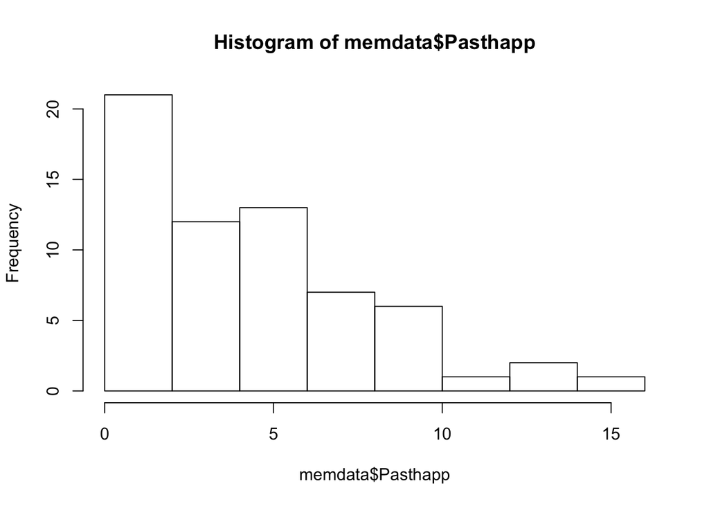

```r
hist(memdata$Pasthapp)
```

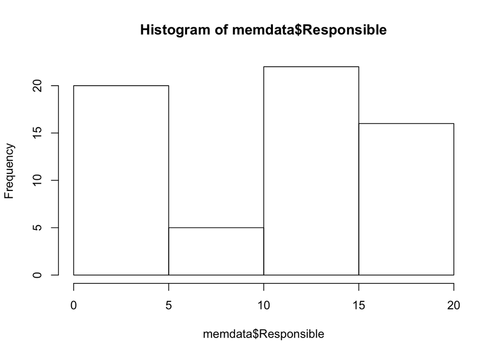

```r
hist(memdata$Responsible)
```

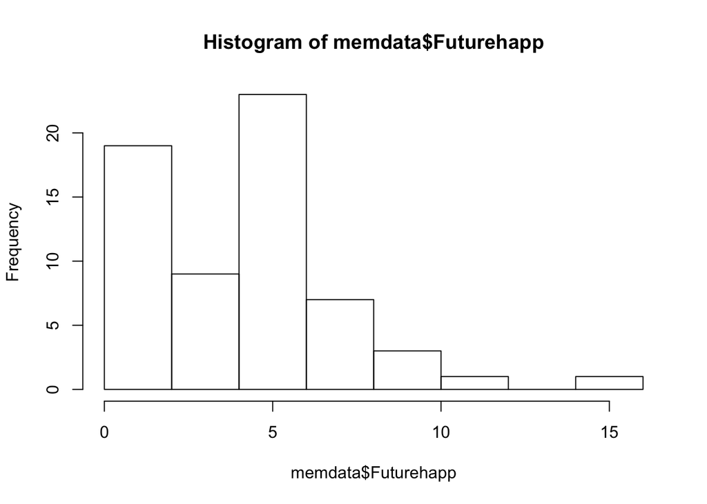

```r
hist(memdata$Futurehapp)
```

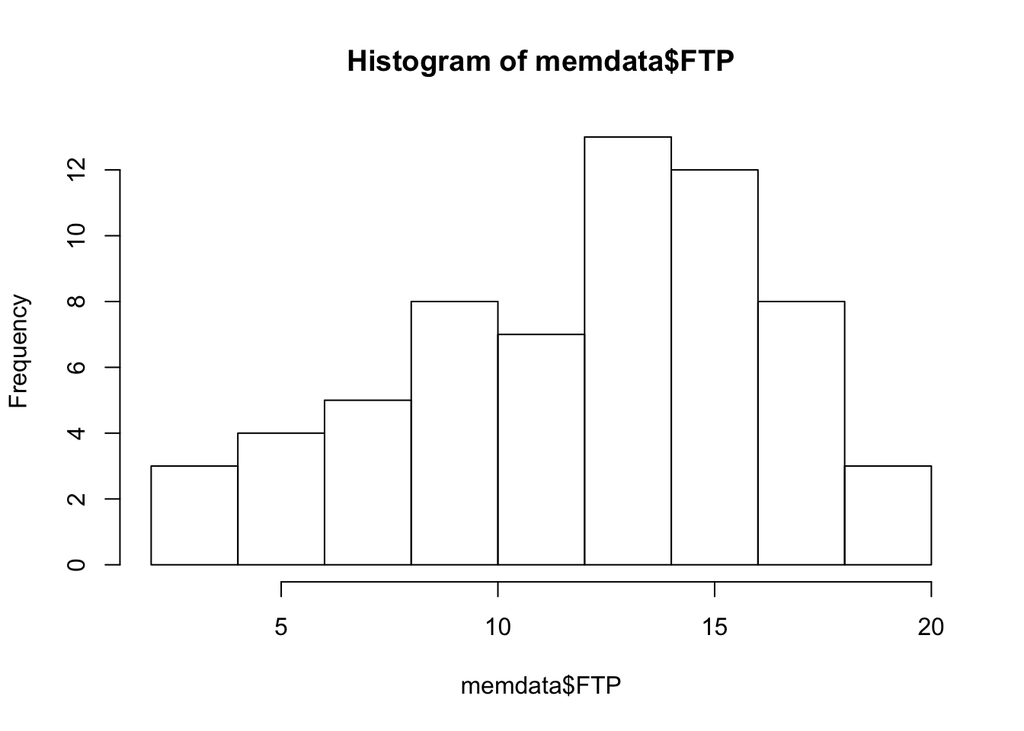

```r
hist(memdata$FTP)
```

```r
memdata$Type <- factor(memdata$Type)
type_names <- c("1" = "Free", "2" = "Biased", "3"="Varied")

# recoding Pasthapp into Low, Med, and High
memdata$pastcat <- findInterval(memdata$Pasthapp, c(0,5,10))
# recoding Responsible into Low and High
memdata$rescat <- findInterval(memdata$Responsible, c(0,10))
# recoding Futurehapp into Low, Med, and High
memdata$futcat <- findInterval(memdata$Futurehapp, c(0,5,10))
# recoding FTP into Low and High
memdata$ftpcat <- findInterval(memdata$FTP, c(0,10))
```

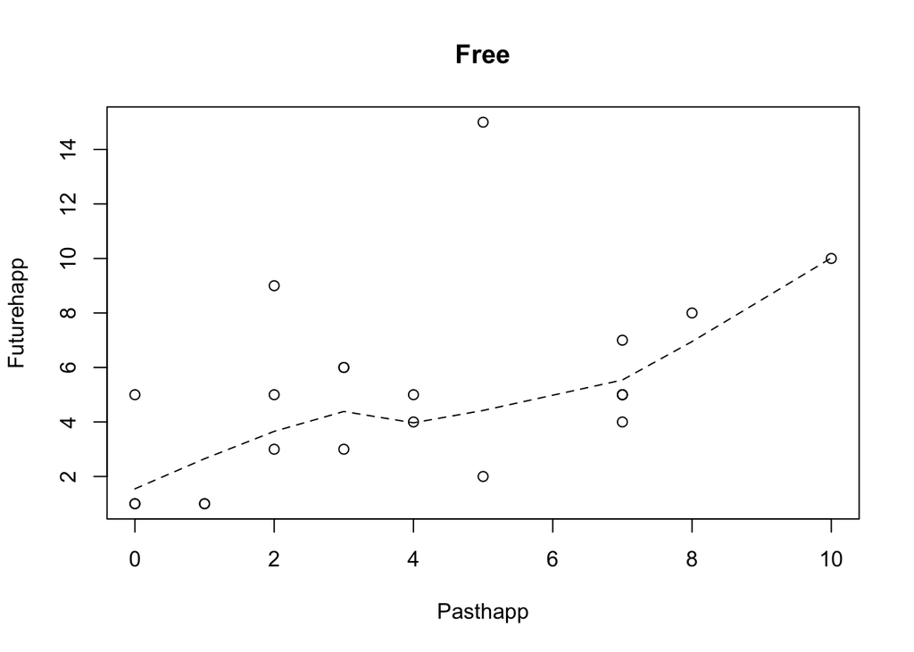

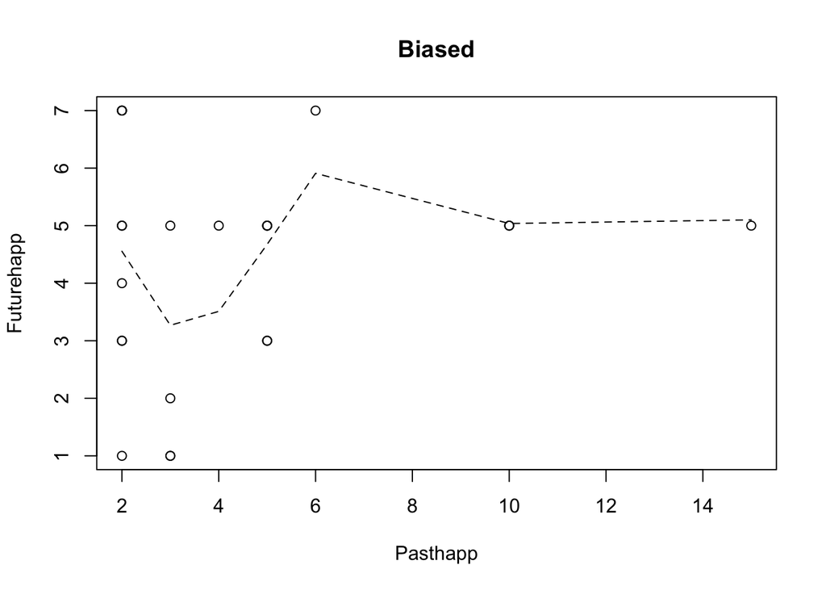

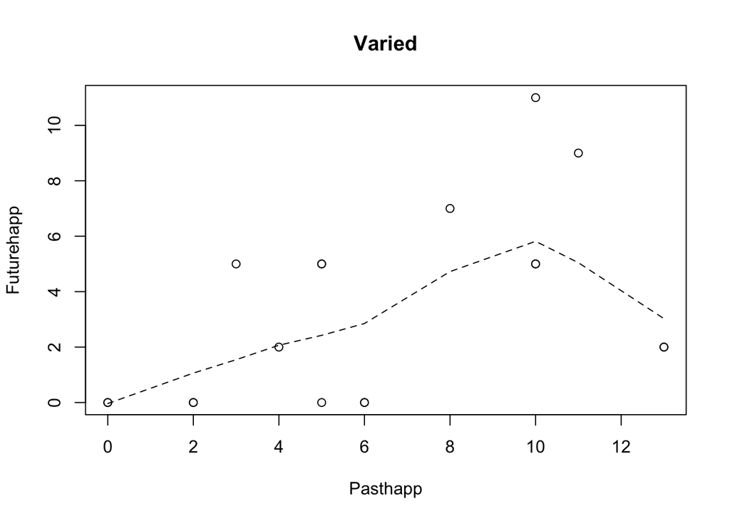

```r
Q6_rs <- vector("list", 3)
for (i in levels(memdata$Type)) {
  Q6_rs[[i]] = cor.test(~ Pasthapp + Futurehapp, memdata, Type==i, na.action=na.omit)
  plot(memdata[memdata$Type==i, c(2,4)], type = 'p', main = type_names[i])
  lines(lowess(memdata[memdata$Type==i, c(2,4)]), lty = 2)
}
```

```r
print(Q6_rs["1"])
```

```
## $`1`
##
##  Pearson's product-moment correlation
##
## data:  Pasthapp and Futurehapp
## t = 2.592, df = 20, p-value = 0.01742
## alternative hypothesis: true correlation is not equal to 0
## 95 percent confidence interval:
##  0.1013 0.7620
## sample estimates:
##    cor
## 0.5015
```

```r
print(Q6_rs["2"])
```

```
## $`2`
##
##  Pearson's product-moment correlation
##
## data:  Pasthapp and Futurehapp
## t = 0.7632, df = 21, p-value = 0.4538
## alternative hypothesis: true correlation is not equal to 0
## 95 percent confidence interval:
##  -0.2659  0.5399
## sample estimates:
##    cor
## 0.1643
```

```r
print(Q6_rs["3"])
```

```
## $`3`
##
##  Pearson's product-moment correlation
##
## data:  Pasthapp and Futurehapp
## t = 2.423, df = 16, p-value = 0.02764
## alternative hypothesis: true correlation is not equal to 0
## 95 percent confidence interval:
##  0.06753 0.79311
## sample estimates:
##    cor
## 0.5181
```

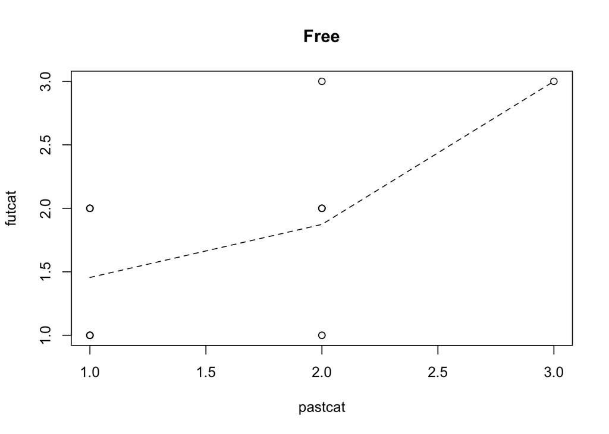

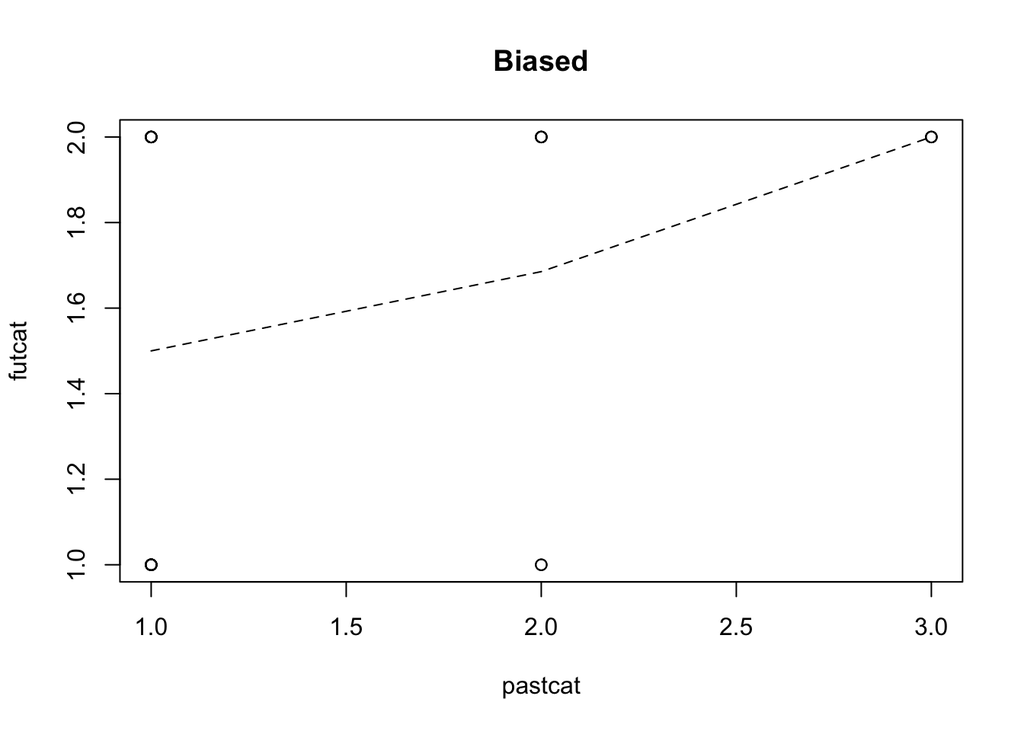

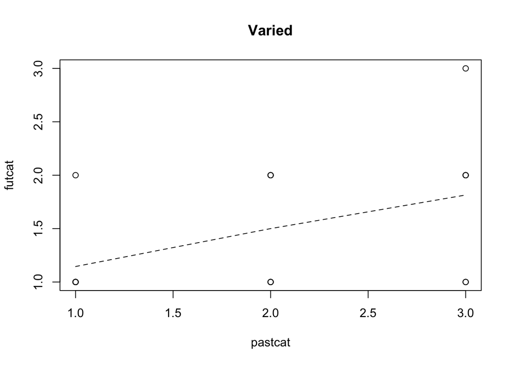

```r
Q6_rs <- vector("list", 3)
for (i in levels(memdata$Type)) {
  Q6_rs[[i]] = cor.test(~ pastcat + futcat, memdata, Type==i, na.action=na.omit)
  plot(memdata[memdata$Type==i, c(7,9)], type = 'p', main = type_names[i])
  lines(lowess(memdata[memdata$Type==i, c(7,9)]), lty = 2)
}
```

```r
print(Q6_rs["1"])
```

```
## $`1`
##
##  Pearson's product-moment correlation
##
## data:  pastcat and futcat
## t = 2.702, df = 20, p-value = 0.01372
## alternative hypothesis: true correlation is not equal to 0
## 95 percent confidence interval:
##  0.1221 0.7707
## sample estimates:
##    cor
## 0.5171
```

```r
print(Q6_rs["2"])
```

```
## $`2`
##
##  Pearson's product-moment correlation
##
## data:  pastcat and futcat
## t = 1.636, df = 21, p-value = 0.1168
## alternative hypothesis: true correlation is not equal to 0
## 95 percent confidence interval:
##  -0.08829  0.65727
## sample estimates:
##    cor
## 0.3361
```

```r
print(Q6_rs["3"])
```

```
## $`3`
##
##  Pearson's product-moment correlation
##
## data:  pastcat and futcat
## t = 2.032, df = 16, p-value = 0.0591
## alternative hypothesis: true correlation is not equal to 0
## 95 percent confidence interval:
##  -0.0177  0.7592
## sample estimates:
##    cor
## 0.4529
```